# ML_1

[figure not shown]

### Overview

- **Linear Regression** is a powerful and widely used technique in machine learning, serving as the **foundation** for many predictive modeling tasks.
- Used to predict **continuous** values.
- It is one of the most important and **mostly used** supervised learning algorithms.
- At its core, Linear Regression aims to establish a **relationship** between a **dependent variable/target** and one or more **independent variables/feature**.

### Types of Linear Regression

1. **Simple Linear Regression**:
   - If a **single** independent variable is used to predict the value of a numerical dependent variable.
1. **Multiple Linear regression**:
   - If **more than one** independent variable is used to predict the value of a numerical dependent variable.

### Linear regression algorithm

[figure not shown]

### Learn by example

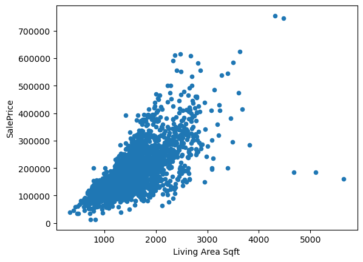

```python
import pandas as pd
df = pd.read_csv("ames-housing.csv")
df.plot.scatter(x='Living Area Sqft', y='SalePrice');
```

[figure not shown]

### Linear equation general form:

[figure not shown]

### How to find the *optimal* line ?

- **Optimizer**: Its primary role is to find the best values for model parameters that minimize the model’s error or loss function.
- Model parameters = weights = coefficients
- Examples of ML Optimizers:
  - **GD**: Gradient Descent)
  - **SGD**: Stochastic Gradient Descent)
  - **Adagrad** (Adaptive Gradient Algorithm)
  - **Adam** (Adaptive Moment Estimation)

## Training a linear regression model

### Execute preprocessing steps

```python
import pandas as pd
from sklearn.model_selection import train_test_split
from sklearn.impute import SimpleImputer
from sklearn.pipeline import make_pipeline
from sklearn.compose import ColumnTransformer
from sklearn.preprocessing import StandardScaler
from sklearn.preprocessing import OneHotEncoder
from sklearn.preprocessing import OrdinalEncoder
from sklearn import set_config
set_config(transform_output='pandas')

df = pd.read_csv("galton_handson.csv")

#Drop non relevant columns
df = df.drop(columns='family')

#Fix inconsistency
df['midparentHeight'] = df['midparentHeight'].str.replace(",", '.')
df['midparentHeight'] =  df['midparentHeight'].astype(float)

df = df.drop_duplicates()

# The target we are trying to predict
y = df['childHeight']
# The features we will use to make the prediction
X = df.drop(columns = 'childHeight')
X.head(5)
```

|  | father | mother | midparentHeight | children | childNum | gender | familySize |
| --- | --- | --- | --- | --- | --- | --- | --- |
| 0 | 78.5 | 67.0 | 75.43 | 4 | 1.0 | male | Mid |
| 1 | 78.5 | 67.0 | 75.43 | 4 | 2.0 | female | Mid |
| 2 | 78.5 | 67.0 | 75.43 | 4 | 3.0 | female | Mid |
| 3 | 78.5 | 67.0 | 75.43 | 4 | 4.0 | female | Mid |
| 4 | 75.5 | 66.5 | 73.66 | 4 | 1.0 | male | Mid |

```python
# Train test split
X_train, X_test, y_train, y_test = train_test_split(X, y, random_state=1)

num_cols = X_train.select_dtypes("number").columns
ordinal_cols = ['familySize']
ohe_cols = X_train.select_dtypes("object").drop(columns=ordinal_cols).columns

########### Numrical pipeline
# instantiate preprocessors
impute_median = SimpleImputer(strategy='median')
scaler = StandardScaler()

# Make a numeric preprocessing pipeline
num_pipe = make_pipeline(impute_median, scaler)

########### Ordinal pipeline
impute_na_ord = SimpleImputer(strategy='constant', fill_value='NA')

# Specifying the order of categories in quality/condition columns
fam_size_order = ["Small", "Mid", "Large"]
# Making the list of order lists for OrdinalEncoder
ordinal_category_orders = [fam_size_order]
# Instantiate the encoder and include the list of ordered values as an argument
ord_encoder = OrdinalEncoder(categories=ordinal_category_orders)

# Making a final scaler to scale category #'s
scaler_ord = StandardScaler()

ord_pipe = make_pipeline(impute_na_ord, ord_encoder, scaler_ord)

######### Nominal pipeline
impute_na = SimpleImputer(strategy='constant', fill_value = "male")

# Instantiate one hot encoder
ohe_encoder = OneHotEncoder(sparse_output=False, handle_unknown='ignore')

# Make pipeline with imputer and encoder
ohe_pipe = make_pipeline(impute_na, ohe_encoder)

######### Build pipelines tuples
num_tuple = ('numeric', num_pipe, num_cols)
ord_tuple = ('ordinal', ord_pipe, ordinal_cols)
ohe_tuple = ('categorical', ohe_pipe, ohe_cols)

######### Create ColumnTransformer
# Instantiate with verbose_feature_names_out=False
col_transformer = ColumnTransformer([num_tuple, ord_tuple, ohe_tuple],
                                    remainder='passthrough',
                                    verbose_feature_names_out=False)

# Fit on training data
col_transformer.fit(X_train)
# Transform the training data
X_train_tf = col_transformer.transform(X_train)
# Transform the testing data
X_test_tf = col_transformer.transform(X_test)
# View the processed training data
X_train_tf
```

|  | father | mother | midparentHeight | children | childNum | familySize | gender_female | gender_male |
| --- | --- | --- | --- | --- | --- | --- | --- | --- |
| 385 | 0.519228 | -0.922169 | -0.260641 | 0.676793 | 1.898582 | 0.813335 | 1.0 | 0.0 |
| 453 | 0.096910 | 1.030101 | 0.834581 | -0.784453 | -0.262833 | -0.698689 | 1.0 | 0.0 |
| 347 | 0.308069 | -0.054494 | 0.210361 | 1.042104 | 1.898582 | 0.813335 | 1.0 | 0.0 |
| 602 | -0.325409 | 0.379344 | 0.091192 | 0.676793 | -0.695116 | 0.813335 | 0.0 | 1.0 |
| 622 | -0.536568 | -0.054494 | -0.357112 | 1.407416 | 1.034016 | 0.813335 | 1.0 | 0.0 |
| ... | ... | ... | ... | ... | ... | ... | ... | ... |
| 767 | -0.958887 | -0.271412 | -0.794066 | 0.676793 | 0.169450 | 0.813335 | 0.0 | 1.0 |
| 72 | 1.448329 | 2.114696 | 2.508626 | 0.676793 | 0.601733 | 0.813335 | 1.0 | 0.0 |
| 908 | -1.592365 | -1.789845 | -2.292194 | -0.419141 | 0.169450 | -0.698689 | 0.0 | 1.0 |
| 235 | 0.730388 | -2.657521 | -1.344514 | -1.515075 | -0.695116 | -2.210713 | 0.0 | 1.0 |
| 37 | 1.997344 | -0.922169 | 0.732436 | 0.676793 | 0.601733 | 0.813335 | 1.0 | 0.0 |

699 rows × 8 columns

### Fit a Linear regression model

```python
from sklearn.linear_model import LinearRegression
# from sklearn.linear_model SGDRegressor
model = LinearRegression()

# Fit the model on the training data
model.fit(X_train_tf, y_train)
model
```

```
LinearRegression()
```

By calling the *fit* function, the model studied the patterns between the features and the target, and found the optimal weights which mimize the loss

### Look to the model parameters/weights:

```python
b_0 = model.intercept_.round(2)
b_i = model.coef_.round(2)
feature_names = col_transformer.get_feature_names_out()
print(f"features: {feature_names}")
print(f"coffiecients (weights): {b_i}")
print(f"intercept (bias): {b_0}")
```

```
features: ['father' 'mother' 'midparentHeight' 'children' 'childNum' 'familySize'
 'gender_female' 'gender_male']
coffiecients (weights): [ 0.63  0.33  0.45  0.58 -1.55  0.19 -1.73  1.73]
intercept (bias): 66.62
```

```python
eq = " +\n".join([ f"{'' if i == 0 else ' '*24}{b_i[i]} * {feature_names[i]}"  for i in range(len(feature_names))])
print(f"Model equation: y_hat = {eq}")
```

```
Model equation: y_hat = 0.63 * father +
                        0.33 * mother +
                        0.45 * midparentHeight +
                        0.58 * children +
                        -1.55 * childNum +
                        0.19 * familySize +
                        -1.73 * gender_female +
                        1.73 * gender_male
```

#### Interpret 0.33 (mother weight):

#### Interpret -1.55 (childNum weight):

#### Interpret -1.73 (gender_F weight):

### Predict new childs

```python
# import numpy as np
new_child = [70, 64, 69.6, 3, 3, 'male', 'Mid']
X = pd.DataFrame(columns=X_train.columns)
X.loc[0] = new_child
X = col_transformer.transform(X)
model.predict(X)
```

```
array([68.24359064])
```

## Model evaluation

[figure not shown]

## Mean Absolute Error (MAE)

[figure not shown]

## Mean Squared Error (MSE)

[figure not shown]

## Which is better, MSE or MAE ?

- Mean squared error penalizes large errors more because the errors are being squared.
- Interpretation is hard

## Root Mean Squared Error (RMSE)

[figure not shown]

## How to decide if the error metrics have acceptable/good values ?

MAE, MSE, and RMSE scores are all dependent on the scale and units of the target. 5,000 USD on the sale of a house isn't too bad, but being off by 5,000 USD on the sale of a car would be horrible!

## R-Squared

- Coefficient of determination
- Describes the percentage of the variation in the target variable that a model can explain by using all the features together.

### Pros:

- Consistent scale

### Cons:

- Difficult to interpret
- A high R2 doesn’t always mean a good model and a low one doesn’t always mean a bad one.

## Let's evaluate our model

```python
# Calculating MSE with sklearn
from sklearn.metrics import mean_squared_error

#Get predictions for test data
y_pred_test = model.predict(X_test_tf)

test_MSE = mean_squared_error(y_test, y_pred_test)
print(f'Model Testing MSE: {test_MSE:,.2f}')
```

```
Model Testing MSE: 3.46
```

## Bias vs. Variance

[output not shown]

### Bias and Variance on LR

[figure not shown]

## High bias (underfitting):

### Reasons:

- A model that is too simple
- Not enough data.
- Features that do not correlate well with the target.

### How to fix:

- Increasing the complexity of your model. (Add more features)
- Adding more data.
- Adding features with higher correlation to the target.

## High Variance (Overfitting)

### Reasons:

- Too complex of a model
- Not enough data.
- Training data that is not a representative sample of the population, all new data the model might encounter.

### How to fix:

- Decrease the complexity of the model. (feature selection)
- Add regularization (you will learn more about this in another lesson).
- Add more data to the training set.
- Ensure that the training set is a representative subset of all data the model will encounter.

### How to detect overfit ?

[figure not shown]

## End-to-End example

```python
import pandas as pd
from sklearn.compose import ColumnTransformer, make_column_selector
from sklearn.linear_model import LinearRegression
from sklearn.pipeline import make_pipeline
from sklearn.preprocessing import StandardScaler, OneHotEncoder
from sklearn.impute import SimpleImputer
from sklearn.model_selection import train_test_split
from sklearn.metrics import r2_score, mean_squared_error, mean_absolute_error
from sklearn import set_config
set_config(transform_output='pandas')
```

```python
df = pd.read_csv('medical_data.csv')
df['Additional_charges'].describe()
```

```
count     1000.000000
mean     13124.934863
std       6677.691402
min       3241.339760
25%       8121.383834
50%      11698.462430
75%      16493.908180
max      30087.650940
Name: Additional_charges, dtype: float64
```

```python
# Drop State
droplist = ['State']
df = df.drop(droplist, axis=1)

# Correct inconsistencies in values in Gender column
df['Gender'] = df['Gender'].replace(['male', 'm', 'M'], 'Male')
df['Gender'] = df['Gender'].replace(['F', 'f'], 'Female')

# Define X and y
X = df.drop(columns='Additional_charges')
y = df['Additional_charges']
# Split the data into train and test sets
X_train, X_test, y_train, y_test = train_test_split(X, y, random_state=42)

# Create the preprocessing pipeline for categorical data
# (New) Select columns with make_column_selector
cat_selector = make_column_selector(dtype_include='object')
# Insantiate transfomers
freq_imputer = SimpleImputer(strategy='most_frequent')
ohe = OneHotEncoder(sparse_output=False, handle_unknown='ignore')
# Instantiate the pipeline
cat_pipe = make_pipeline(freq_imputer, ohe)
# Make a tuple for column transformer
cat_tuple = ('categorical',cat_pipe, cat_selector)

# Create the preprocessing pipeline for numeric data
# (New) Select columns wiht make_column)selector
num_selector = make_column_selector(dtype_include='number')
# Instantiate the transformers
scaler = StandardScaler()
mean_imputer = SimpleImputer(strategy='mean')
# Instantiate the pipeline
num_pipe = make_pipeline(mean_imputer, scaler)
# Make the tuple for ColumnTransformer
num_tuple = ('numeric',num_pipe, num_selector)

# Create the preprocessing ColumnTransformer
preprocessor = ColumnTransformer([cat_tuple, num_tuple],
                                 verbose_feature_names_out=False)
```

### Create model pipeline

```python
# Instantiate a linear regression model
model = LinearRegression()
# Combine the preprocessing ColumnTransformer and the linear regression model in a Pipeline
model_pipe = make_pipeline(preprocessor, model)
model_pipe
```

```
Pipeline(steps=[('columntransformer',
                 ColumnTransformer(transformers=[('categorical',
                                                  Pipeline(steps=[('simpleimputer',
                                                                   SimpleImputer(strategy='most_frequent')),
                                                                  ('onehotencoder',
                                                                   OneHotEncoder(handle_unknown='ignore',
                                                                                 sparse_output=False))]),
                                                  <sklearn.compose._column_transformer.make_column_selector object at 0x7fa3282ff610>),
                                                 ('numeric',
                                                  Pipeline(steps=[('simpleimputer',
                                                                   SimpleImputer()),
                                                                  ('standardscaler',
                                                                   StandardScaler())]),
                                                  <sklearn.compose._column_transformer.make_column_selector object at 0x7fa3252ce8c0>)],
                                   verbose_feature_names_out=False)),
                ('linearregression', LinearRegression())])
```

### Fit the model pipeline on the training data

```python
model_pipe.fit(X_train, y_train)
```

```
Pipeline(steps=[('columntransformer',
                 ColumnTransformer(transformers=[('categorical',
                                                  Pipeline(steps=[('simpleimputer',
                                                                   SimpleImputer(strategy='most_frequent')),
                                                                  ('onehotencoder',
                                                                   OneHotEncoder(handle_unknown='ignore',
                                                                                 sparse_output=False))]),
                                                  <sklearn.compose._column_transformer.make_column_selector object at 0x7fa3282ff610>),
                                                 ('numeric',
                                                  Pipeline(steps=[('simpleimputer',
                                                                   SimpleImputer()),
                                                                  ('standardscaler',
                                                                   StandardScaler())]),
                                                  <sklearn.compose._column_transformer.make_column_selector object at 0x7fa3252ce8c0>)],
                                   verbose_feature_names_out=False)),
                ('linearregression', LinearRegression())])
```

### Model evaluation

```python
def regression_metrics(y_true, y_pred, label='', verbose = True, output_dict=False):
    # Get metrics
    mae = mean_absolute_error(y_true, y_pred)
    mse = mean_squared_error(y_true, y_pred)
    rmse = mean_squared_error(y_true, y_pred, squared=False)
    r_squared = r2_score(y_true, y_pred)
    if verbose == True:
        # Print Result with Label and Header
        header = "-"*60
        print(header, f"Regression Metrics: {label}", header, sep='\n')
        print(f"- MAE = {mae:,.3f}")
        print(f"- MSE = {mse:,.3f}")
        print(f"- RMSE = {rmse:,.3f}")
        print(f"- R^2 = {r_squared:,.3f}")
    if output_dict == True:
        metrics = {'Label':label, 'MAE':mae,
                 'MSE':mse, 'RMSE':rmse, 'R^2':r_squared}


# Get predictions for training data
y_train_pred = model_pipe.predict(X_train)

# Call the helper function to obtain regression metrics for training data
results_train = regression_metrics(y_train, y_train_pred, label='Training Data')
print()
# Get predictions for test data
y_test_pred = model_pipe.predict(X_test)
# Call the helper function to obtain regression metrics for test data
results_test = regression_metrics(y_test, y_test_pred, label='Test Data' )
```

```
------------------------------------------------------------
Regression Metrics: Training Data
------------------------------------------------------------
- MAE = 1,376.776
- MSE = 2,609,667.246
- RMSE = 1,615.446
- R^2 = 0.943

------------------------------------------------------------
Regression Metrics: Test Data
------------------------------------------------------------
- MAE = 1,366.751
- MSE = 2,747,847.920
- RMSE = 1,657.663
- R^2 = 0.933
```

### Assignment 7

- Explore Kaggle and select a dataset for regression modeling. Ensure the dataset adheres to the following criteria:
  - Must include at least 5 features (excluding the target), with a mix of ordinal and nominal features.
  - The target feature must be numeric.
- Perform necessary data cleaning and preprocessing, The splitting of the data should use 80% train and 20% test ratio. **Use your student ID as the random_state when splitting**.
- Fit a linear regression model on the transformed data.
- Print the model parameters and provide an interpretation for each.
- Evaluate the model's quality using appropriate metrics.
- Determine if the model exhibits overfitting or underfitting and explain your reasoning.
- Provide link to your selected data set in Kaggle.

**Any attempt of using generative AI will be considered as cheating !**